# Communicate Data Findings - Loan Data from Prosper

## by Abha Ramchandani

## Investigation Overview

> The fact that we are investigating Loan data, the fisrt question that comes to my mind is 'how do I pay the least interest?'

> That led me to investigate all the factors/variables that affect the interest rate, represented by BorrowerAPR in the given data.

## Dataset Overview

> The loan dataset has been provided in a CSV file. It contains 113,937 records and 81 variables about each loan data, including loan amount, borrower rate (or interest rate), current loan status, etc. It also contains those listings which didn't transformed into a loan. There is also information on partially funded loans in the dataset.

## What factors influence the Interest Rates / BorrowerAPR?

> Let's review how the prosper rate and so the Borrower APR is influenced. Quite intuitively, ProsperScore (Alpha) is a valuable evaluation metric, also confirmed by our analysis.

> After having made some initial Univariate and Bivariate observations, we will look at how Term, ProsperRating, StatedMonthyIncome and LoanOriginalAmount and a combinations of these variables affect BorrowerAPR and each other.

## Effect of ProsperRating and Term on BorrowerAPR & its relationships with LoanOriginalAmount and StatedMonthlyIncome

### BorrowerAPR vs Term and ProsperRating (Alpha)

> As ProsperRating gets better HR>AA, the BorrowerAPR decreases.

> Generally speaking, for ProsperRating HR>C, BorrowerAPR generally decreses with increase in length of loan Term. This reverses as we go from ProsperRating B>AA

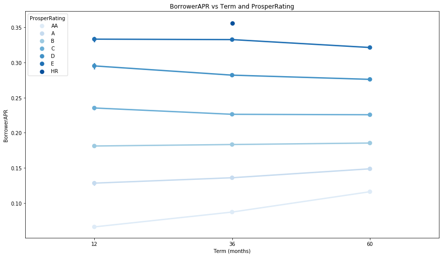

```python
# Plot BorrowerAPR vs Term and ProsperRating (Alpha)
plt.figure(figsize = [14.70, 8.27])

ax = sb.pointplot(data = df_copy, x = 'Term', y = 'BorrowerAPR', hue = 'ProsperRating (Alpha)',
                   palette = 'Blues');
plt.legend(loc = 2, title = 'ProsperRating');
plt.xlabel('Term (months)');
plt.title('BorrowerAPR vs Term and ProsperRating', color = 'black');
```

### BorrowerAPR vs Term and LoanOriginalAmount

> 36-month Term has most number of loans, followed by 60-month and 12-month Terms.

> There are more loans for lower LoanOriginalAmount in all the terms.

> As LoanOriginalAmount increases BorrowerAPR decreases.

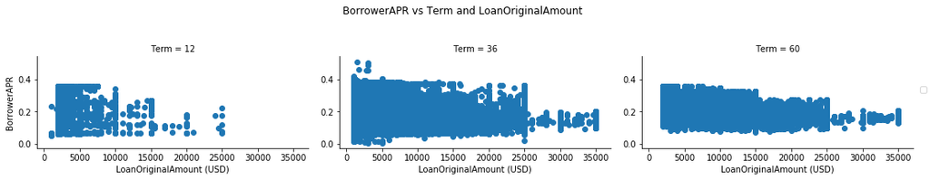

```python
# Plot BorrowerAPR vs Term and LoanOriginalAmount
#plt.figure(figsize = [14.70, 8.27])
g = sb.FacetGrid(data = df_copy, size = 3, aspect = 1.7, col = 'Term')
g.map(plt.scatter, 'LoanOriginalAmount', 'BorrowerAPR').set_axis_labels("LoanOriginalAmount (USD)", "BorrowerAPR");
g.fig.suptitle('BorrowerAPR vs Term and LoanOriginalAmount', color = 'black');
plt.subplots_adjust(top = 0.7)
g.add_legend();
```

### BorrowerAPR vs Term and StatedMonthlyIncome

> Generally speaking, higher the StatedMonthlyIncome, lower the BorrowerAPR.

```python
# Plot BorrowerAPR vs Term and StatedMonthlyIncome
#plt.figure(figsize = [14.70, 8.27])
g = sb.FacetGrid(data = df_copy, size = 3, aspect = 1.7, col = 'Term')
g.map(plt.scatter, 'StatedMonthlyIncome', 'BorrowerAPR').set_axis_labels("StatedMonthlyIncome (USD)", "BorrowerAPR");
plt.suptitle('BorrowerAPR vs Term and StatedMonthlyIncome', color = 'black');
plt.subplots_adjust(top = 0.7);
g.add_legend();
```

[output not shown]

### PropsperRating vs. (LoanOriginalAmount, StatedMonthlyIncome and BorrowerAPR)

> Better ProsperRating means better BorrowerAPR

> Better ProsperRating means higher loan amounts are approved

> There is no significant relationship between StateMonthlyIncome and ProsperRating (Alpha). People in any income range can have good as well poor ProsperRating

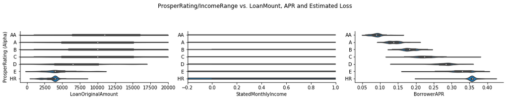

```python
# Plot all PropsperRating vs. (LoanOriginalAmount, StatedMonthlyIncome and BorrowerAPR)
base_color = sb.color_palette()[0]
#plt.figure(figsize = [14.70, 8.27])

# Plot matrix: sample 7000 so that plots are clearer and they render faster
samples = np.random.choice(df_copy.shape[0], 7000, replace = False)
pairplot_sample = df_copy.iloc[samples,:]

# Plot
g = sb.PairGrid(data = pairplot_sample,
                x_vars = ['LoanOriginalAmount', 'StatedMonthlyIncome','BorrowerAPR'],
                y_vars = ['ProsperRating (Alpha)'],
                size = 3, aspect = 1.7, dropna = True)

g.map(sb.violinplot,  color = base_color, saturation = 2);
g.axes[0,0].set_xlim(-1000,20000)
g.axes[0,1].set_xlim(-0.2,1)
g.fig.suptitle('ProsperRating/IncomeRange vs. LoanMount, APR and Estimated Loss', fontdict={'fontsize': 18}, color = 'black');
g.fig.subplots_adjust(top = 0.7)


for i in np.arange(g.axes.shape[0]):
    for j in np.arange(g.axes.shape[1]):
        g.axes[i,j].grid(False)
```